# Shopee: Predicting User Behavior for Marketing Campaign

[figure not shown]

## Highlights

- Catboost outperforms other models (including NN) with little preprocessing
- New model: RuleFit, discussed how it can be used as a model interpretability
- New resampling technique: SMOTENC, discussed how it helps improve the accuracy of the model
- New model interpretability: ALE plots, as an alternative to PDP plots
- open_count, subject length, country, and age as top predictor for predicting user opening an email

### Install Dependencies

```python
!pip install -qq catboost
!pip install -qq shap
!pip install git+https://github.com/MaximeJumelle/ALEPython.git@dev#egg=alepython
!pip install git+git://github.com/christophM/rulefit.git
```

```
     |████████████████████████████████| 76.3 MB 12 kB/s
     |████████████████████████████████| 371 kB 5.3 MB/s
  Installing build dependencies ... done
  Getting requirements to build wheel ... done
    Preparing wheel metadata ... done
```

## Exploratory Data Analysis

### Imports

```python
# python standard libraries
from datetime import datetime
import time
import sys
import re

# data processing
import pandas as pd
import numpy as np
from tqdm import tqdm

# plotting
from pandas.plotting import scatter_matrix
from matplotlib import cm
import seaborn as sns
import matplotlib.patches as mpatches
import pylab as plot
import matplotlib.pyplot as plt

# model interpretability
from alepython import ale_plot
import shap


# normalize
from sklearn.preprocessing import StandardScaler
from sklearn.preprocessing import MinMaxScaler

# model selection
from sklearn.model_selection import train_test_split
from sklearn.model_selection import KFold
from sklearn.model_selection import StratifiedKFold
from sklearn.model_selection import RepeatedStratifiedKFold
from sklearn.model_selection import RepeatedKFold
from sklearn.model_selection import ParameterGrid
from sklearn.model_selection import GridSearchCV

# ml models
# error based models
from sklearn.linear_model import LinearRegression
from sklearn.linear_model import Lasso
from sklearn.linear_model import Ridge
from sklearn.linear_model import LogisticRegression
from sklearn.svm import LinearSVC
from sklearn.svm import SVC

# information based models
from sklearn.tree import DecisionTreeRegressor
from sklearn.ensemble import RandomForestRegressor
from sklearn.ensemble import GradientBoostingRegressor
from sklearn.tree import DecisionTreeClassifier
from sklearn.ensemble import RandomForestClassifier
from sklearn.ensemble import GradientBoostingClassifier

# similarity based
from sklearn.neighbors import KNeighborsRegressor
from sklearn.neighbors import KNeighborsClassifier

# Additional models
from rulefit import RuleFit
from catboost import CatBoostClassifier, Pool

# resampling techniques
from imblearn.over_sampling import SMOTE, ADASYN, SMOTENC

# scoring metrics
from sklearn.metrics import r2_score
from sklearn.metrics import confusion_matrix
from sklearn.metrics import accuracy_score
from sklearn.metrics import matthews_corrcoef

# ignore warnings
import warnings
from sklearn.exceptions import ConvergenceWarning
warnings.filterwarnings("ignore", category=FutureWarning)
warnings.filterwarnings("ignore", category=RuntimeWarning)
warnings.filterwarnings("ignore", category=ConvergenceWarning)


from IPython.display import HTML
import calendar
```

```python
# Toggle codes and center figures
HTML('''<script>
code_show=false;
function code_toggle() {
 if (code_show){
 $('div.input').hide();
 } else {
 $('div.input').show();
 }
 code_show = !code_show
}
$( document ).ready(code_toggle);
</script>
<form action="javascript:code_toggle()">
<input type="submit" value="Click to toggle on/off the raw code.">
</form>''')
```

### Extract Dataset

The data was fetch from [kaggle](https://www.kaggle.com/c/open-shopee-code-league-marketing-analytics) containing three csv files namely: `train.csv`, `test.csv`, and `users.csv`. train and test csv have similar features except that there is no `open_flag` for test.csv.

```python
from google.colab import drive
drive.mount('/content/gdrive', force_remount=True)
```

```python
!cp /content/gdrive/MyDrive/MSDS/ML1/project/*.csv .
```

```python
df_train = pd.read_csv('train.csv')
df_test = pd.read_csv('test.csv')
df_users = pd.read_csv('users.csv')
```

**Table 1. Data Description of train/test.csv.**

| Column | Description |
| --- | --- |
| `country_code` | An integer code for the country where the user lives. |
| `grass_date` | The date when the email was sent. |
| `user_id` | the unique identifier of each user |
| `subject_line_length` | the number of characters in the subject of the email |
| `last_open_day` | How many days ago was the last time the user opened an email |
| `last_login_day` | How many days ago the user last logged in its Shopee account |
| `last_checkout_day` | How many days ago the user last purchased on Shopee |
| `open_count_last_[10/30/60]_days` | the total number of email opens in the last N days. |
| `login_count_last_[10/30/60]_days` | the total number of user logins in the last N days. |
| `checkout_count_last_[10/30/60]_days` | the total number of checkouts (=purchases) by the user in the last N days. |
| `open_flag` | the target variable. Whether or not the email was opened. |

```python
display(HTML('''<p style="font-size:12px;font-style:default;">
<b>Table 2. Snippet of train.csv.</b></p>'''))
display(df_train.tail())
```

**Table 2. Snippet of train.csv.**

|  | country_code | grass_date | user_id | subject_line_length | last_open_day | last_login_day | last_checkout_day | open_count_last_10_days | open_count_last_30_days | open_count_last_60_days | login_count_last_10_days | login_count_last_30_days | login_count_last_60_days | checkout_count_last_10_days | checkout_count_last_30_days | checkout_count_last_60_days | open_flag | row_id |
| --- | --- | --- | --- | --- | --- | --- | --- | --- | --- | --- | --- | --- | --- | --- | --- | --- | --- | --- |
| 73534 | 6 | 2019-09-02 00:00:00+08:00 | 127613 | 39 | 24 | 36 | 279 | 0 | 1 | 1 | 0 | 0 | 0 | 0 | 0 | 0 | 0 | 73534 |
| 73535 | 2 | 2019-09-02 00:00:00+08:00 | 127620 | 38 | 46 | 10 | 51 | 0 | 0 | 1 | 0 | 0 | 0 | 0 | 0 | 0 | 0 | 73535 |
| 73536 | 2 | 2019-09-02 00:00:00+08:00 | 127696 | 32 | Never open | Never login | Never checkout | 0 | 0 | 0 | 0 | 0 | 0 | 0 | 0 | 0 | 0 | 73536 |
| 73537 | 2 | 2019-09-02 00:00:00+08:00 | 127807 | 38 | 5 | 34 | Never checkout | 2 | 4 | 4 | 0 | 0 | 0 | 0 | 0 | 0 | 1 | 73537 |
| 73538 | 6 | 2019-09-02 00:00:00+08:00 | 127880 | 39 | 1 | 3 | Never checkout | 2 | 2 | 3 | 0 | 0 | 0 | 0 | 0 | 0 | 0 | 73538 |

**Table 3. Data Description of users.csv.**

| Column | Description |
| --- | --- |
| `user_id` | the unique identifier of each user |
| `attr_[1/2/3]` | general user attributes. Attr_1 and attr_2 are boolean, attrib_3 is categorical (can be integer [0,1,2,3,4]) |
| `age` | The user's reported age. |
| `domain` | The user's top-level email domain. Less common domains are bundled together under the label 'other'. |

```python
display(HTML('''<p style="font-size:12px;font-style:default;">
<b>Table 4. Raw data of users.csv.</b></p>'''))
display(df_users.head())
```

**Table 4. Raw data of users.csv.**

|  | user_id | attr_1 | attr_2 | attr_3 | age | domain |
| --- | --- | --- | --- | --- | --- | --- |
| 0 | 0 | NaN | 1.0 | 0.0 | NaN | @gmail.com |
| 1 | 1 | 1.0 | 1.0 | 2.0 | 50.0 | @gmail.com |
| 2 | 2 | NaN | 1.0 | 0.0 | NaN | other |
| 3 | 3 | NaN | 1.0 | 0.0 | NaN | @gmail.com |
| 4 | 4 | 1.0 | 1.0 | 2.0 | 33.0 | @gmail.com |

### Distribution of data

First, let us see if our target variable is balanced meaning there are almost equal count of users who opened their emails and not.

**Figure 1. Class distribution on train data**

Most users **do not** open their emails

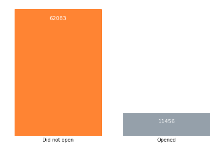

```python
display(HTML('''<p style="font-size:12px;font-style:default;"><b>
Figure 1. Class distribution on train data</b></p>'''))

display(HTML(f'''<h3>
                &nbsp;&nbsp;&nbsp;&nbsp;&nbsp;&nbsp;&nbsp;&nbsp;
                &nbsp;&nbsp;&nbsp;&nbsp;&nbsp;&nbsp;
                Most users <b style="color:#FF6600">
                do not</b> open their emails
                </h3>'''))


fig, ax = plt.subplots(figsize=(8, 5))
bar_data = df_train['open_flag'].value_counts()
bar_data.index = ['Did not open', 'Opened']
ax = sns.barplot(x=bar_data.index, y=bar_data.values, color='lightslategrey',
                 ax=ax, alpha=0.8)

# remove the frame of the chart
for spine in plt.gca().spines.values():
    spine.set_visible(False)

ax.tick_params(axis='both', which='both', length=0)
ax.axes.yaxis.set_ticks([]);
for bar in ax.containers[0]:
    plt.gca().text(bar.get_x() + bar.get_width()/2, bar.get_height() - 5000,
                   str(int(bar.get_height())),
                 ha='center', color='w', fontsize=11)

ax.containers[0][0].set_color('#FF6600')
```

There are 5x more users who do not open an e-mail coming from shopee than that of who opened

Let us now check the distribution of our features from train and test data using histograms.

**Figure 2. Distribution of features on train and test data**

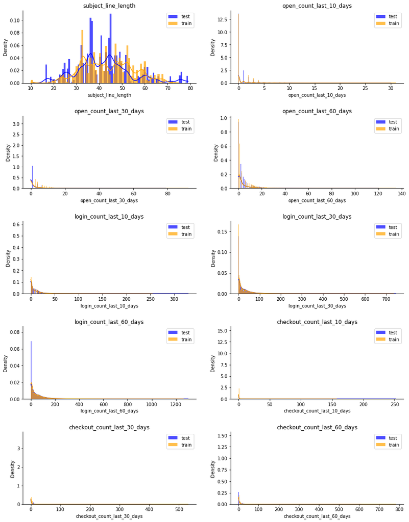

```python
display(HTML('''<center style="font-size:12px;font-style:default;"><b>
Figure 2. Distribution of features on train and test data</b></center>'''))

i, j = 0, 0
fig, axes = plt.subplots(5, 2, figsize = (15, 20))
plt.subplots_adjust(hspace = .45)

for col in df_train.columns[1:]:
    if col in ['user_id', 'grass_date', 'row_id', 'open_flag',
              'last_login_day', 'last_checkout_day', 'last_open_day']:
        continue
    else:
        sns.histplot(df_test[col], ax=axes[i,j],
                     label='test', color='blue', alpha=0.7,
                     kde=True, stat="density", linewidth=0)
        sns.histplot(df_train[col], ax=axes[i,j],
                     label='train', color='orange', alpha=0.7,
                     kde=True, stat="density", linewidth=0)

        axes[i,j].legend()
    axes[i, j].set_title(col)
    axes[i, j].spines['top'].set_visible(False)
    axes[i, j].spines['right'].set_visible(False)

    j += 1
    if j == 2:
        i += 1
        j = 0
```

**Insights:**

- Most of the features are right skewed
- Train and test data came from the same distribution

Let's also see on how our users.csv distributed.

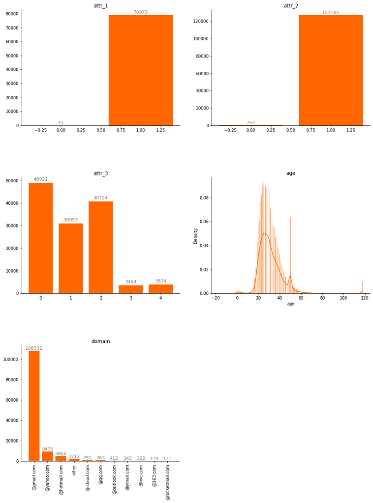

```python
display(HTML('''<center style="font-size:12px;font-style:default;"><b>
Figure 3. Distribution on train and test data</b></center>'''))


i, j = 0, 0
fig, axes = plt.subplots(3, 2, figsize = (15, 20))
plt.subplots_adjust(hspace = .45)

for col in df_users.columns[1:]:
    if col in ['user_id']:
        continue
    elif col == 'age':
        sns.histplot(df_users[col], ax=axes[i,j], color='#FF6600',
                     kde=True, stat="density", linewidth=0)
    else:
        bar_data = df_users[col].value_counts()
        bars = axes[i,j].bar(bar_data.index, bar_data.values, color='#FF6600')

        for bar in bars:
            axes[i,j].text(bar.get_x() + bar.get_width()/2, bar.get_height()
                           + 1000, str(int(bar.get_height())),
                 ha='center', color='gray', fontsize=11)
        if i == 2 and j == 0:
            for item in axes[i,j].xaxis.get_ticklabels():
                item.set_rotation(90)

    axes[i, j].set_title(col)
    axes[i, j].spines['top'].set_visible(False)
    axes[i, j].spines['right'].set_visible(False)

    j += 1
    if j == 2:
        i += 1
        j = 0

fig.delaxes(axes[2,1])
```

**Insights**

- `attr_1` and `attr_2` are highly imbalanced data
- `gmail` are most preferred email account by users
- There are some age that are negative and some are even 118 years old (older than that of oldest person in the world. (Reference: [link](https://www.washington.edu/news/2021/07/01/how-long-can-a-person-live-the-21st-century-may-see-a-record-breaker/#:~:text=The%20oldest%20living%20person%2C%20Jeanne,old%20Kane%20Tanaka%20of%20Japan.) )

Using box plot, we can further see how skewed our data and if it is in the same scale with other features

**Figure 4. Boxplot representation of train and test data**

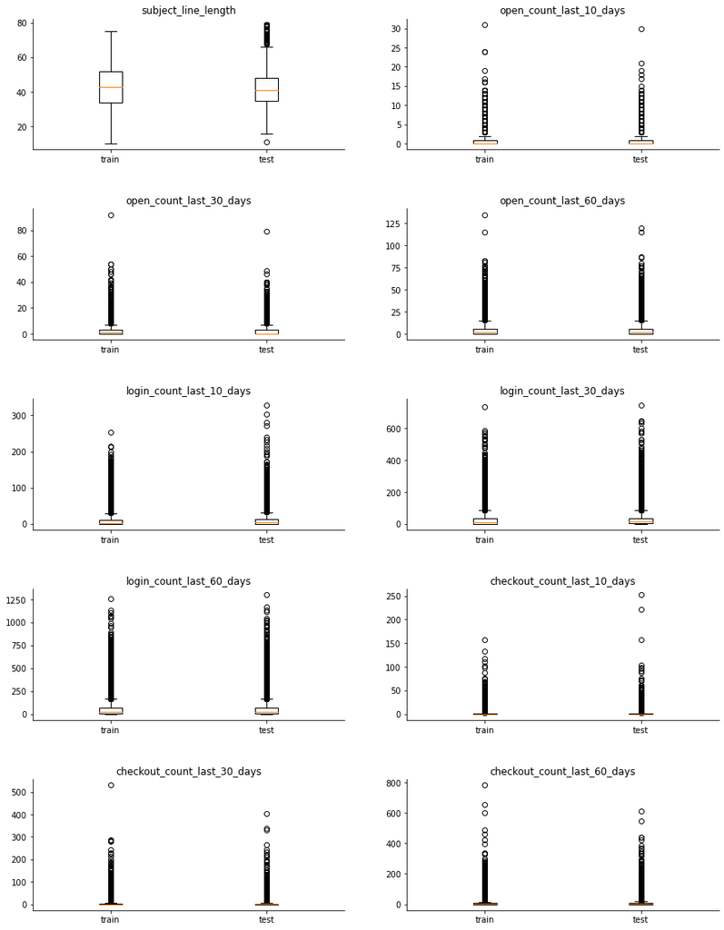

```python
display(HTML('''<p style="font-size:12px;font-style:default;"><b>
Figure 4. Boxplot representation of train and test data</b></p>'''))

i, j = 0, 0
fig, axes = plt.subplots(5, 2, figsize = (15, 20))
plt.subplots_adjust(hspace = .45)

for col in df_train.columns[1:]:
    if col in ['user_id', 'grass_date', 'row_id', 'open_flag',
               'last_login_day', 'last_checkout_day', 'last_open_day']:
        continue
    else:
        axes[i,j].boxplot([df_train[col],df_test[col]],
                          labels=['train','test'])

    axes[i, j].set_title(col)
    axes[i, j].spines['top'].set_visible(False)
    axes[i, j].spines['right'].set_visible(False)

    j += 1
    if j == 2:
        i += 1
        j = 0
```

**Insights**

- Some features are not in the same scale
- Some features have a very high values relative to the mean that could signal an outlier

### Correctness of Data

We now check if the open/login/checkout days are consistent to each other.

```python
print('Train:')
for activity in ['open', 'login', 'checkout']:
    for initdays, findays in zip([10, 30], [30, 60]):
        initcol =  '{}_count_last_{}_days'.format(activity, initdays)
        fincol = '{}_count_last_{}_days'.format(activity, findays)
        count = len(df_train[(df_train[initcol] > df_train[fincol])])
        print(f'Count of {initcol} > {fincol}: {count}')
```

```
Train:
Count of open_count_last_10_days > open_count_last_30_days: 0
Count of open_count_last_30_days > open_count_last_60_days: 0
Count of login_count_last_10_days > login_count_last_30_days: 0
Count of login_count_last_30_days > login_count_last_60_days: 0
Count of checkout_count_last_10_days > checkout_count_last_30_days: 0
Count of checkout_count_last_30_days > checkout_count_last_60_days: 0
```

```python
print('Test:')
for activity in ['open', 'login', 'checkout']:
    for initdays, findays in zip([10, 30], [30, 60]):
        initcol =  '{}_count_last_{}_days'.format(activity, initdays)
        fincol = '{}_count_last_{}_days'.format(activity, findays)
        count = len(df_test[(df_test[initcol] > df_test[fincol])])
        print(f'Count of {initcol} > {fincol}: {count}')
```

```
Test:
Count of open_count_last_10_days > open_count_last_30_days: 0
Count of open_count_last_30_days > open_count_last_60_days: 0
Count of login_count_last_10_days > login_count_last_30_days: 0
Count of login_count_last_30_days > login_count_last_60_days: 0
Count of checkout_count_last_10_days > checkout_count_last_30_days: 0
Count of checkout_count_last_30_days > checkout_count_last_60_days: 0
```

**Insights**

- Data is consistent for the following features

### Correlations

**Figure 5. Pearson pairwise correlation of train data**

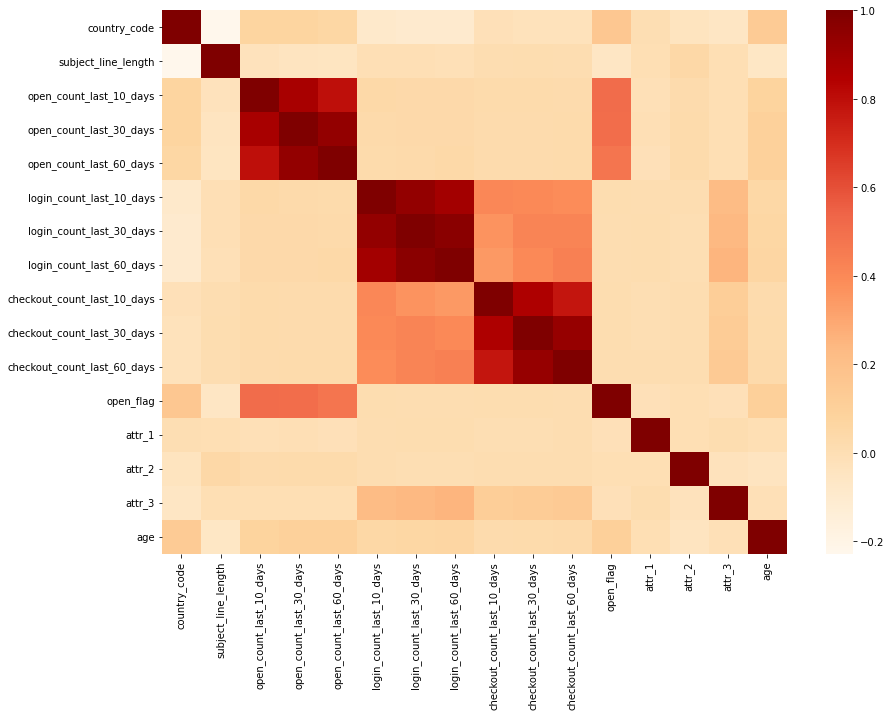

```python
display(HTML('''<p style="font-size:12px;font-style:default;"><b>
Figure 5. Pearson pairwise correlation of train data</b></p>'''))

fig = plt.subplots(1, 1, figsize = (14,10))
df_train_merge = (pd.merge(df_train, df_users, how='inner', on='user_id')
                  .drop(['user_id', 'row_id'], axis=1))
df_test_merge = (pd.merge(df_test, df_users, how='inner', on='user_id')
                 .drop(['user_id', 'row_id'], axis=1))
corr = df_train_merge.corr()
sns.heatmap(corr, cmap='OrRd');
```

**Insights:**

- Open_count seems to correlate well with our target variable `open_flag`
- There is a high correlation between open/login/checkout counts on different days

**Figure 6. Pairplot of train data**

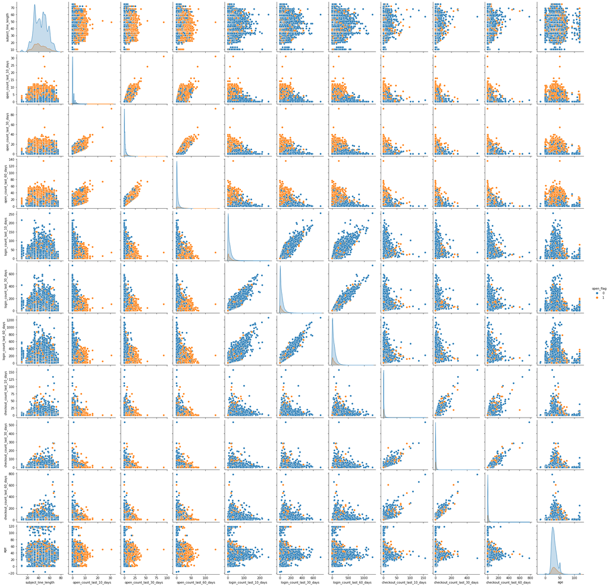

```python
display(HTML('''<p style="font-size:12px;font-style:default;"><b>
Figure 6. Pairplot of train data</b></p>'''))

cols = list(df_train.columns)
cat_vars = ['user_id', 'row_id', 'country_code', 'grass_date',
            'attr_1', 'attr_2', 'attr_3', 'domain']
sns.pairplot(df_train_merge.loc[:, ~df_train_merge.columns.isin(cat_vars)].dropna(),
             hue='open_flag');
```

**Insights:**

- Similar to the correlation, we can clearly see in the figure above that the higher the number of counts the likely that a customer will open the email.
- For all other features, it is hard to determine if there is a bivariate relationship to the target variable

Zooming in on the `open_count` features

**Figure 7. Open count in 3D**

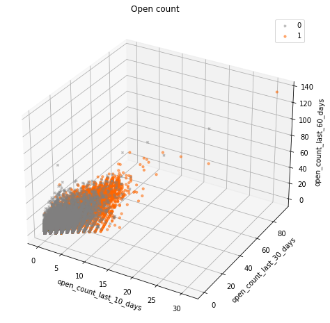

```python
display(HTML('''<p style="font-size:12px;font-style:default;"><b>
Figure 7. Open count in 3D</b></p>'''))

fig = plt.figure(figsize=(8,8))
ax = fig.add_subplot(111, projection = '3d')


a = ax.scatter(df_train[df_train.open_flag == 0].open_count_last_10_days,
               df_train[df_train.open_flag == 0].open_count_last_30_days,
               df_train[df_train.open_flag == 0].open_count_last_60_days,
               c = 'gray', label = 0, marker = 'x', s=10, alpha=0.5 )
b = ax.scatter(df_train[df_train.open_flag == 1].open_count_last_10_days,
               df_train[df_train.open_flag == 1].open_count_last_30_days,
               df_train[df_train.open_flag == 1].open_count_last_60_days,
               c = '#FF6600', label = 1, marker = 'o', s=10, alpha=0.5 )
ax.set_xlabel('open_count_last_10_days')
ax.set_ylabel('open_count_last_30_days')
ax.set_zlabel('open_count_last_60_days')
ax.legend()
ax.set_title('Open count ');
```

We can see that indeed the more a user open an email within 2 months then they are likely to open it again.

**Figure 8. Seasonality of users opening their emails in 2 months period**

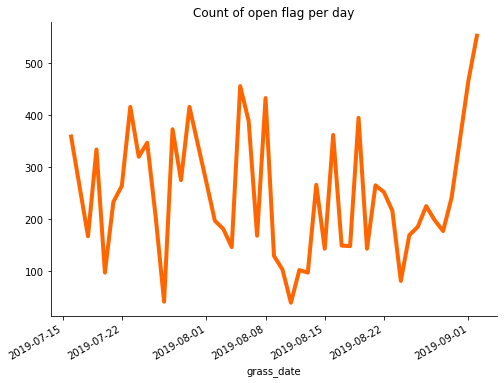

```python
display(HTML('''<p style="font-size:12px;font-style:default;"><b>
Figure 8. Seasonality of users opening their emails in 2 months period
</b></p>'''))

df_train['grass_date'] = pd.to_datetime(df_train['grass_date'])
ax = (df_train.groupby('grass_date')['open_flag']
      .sum().plot(figsize=(8, 6), color='#FF6600', lw=4))

ax.set_title('Count of open flag per day')
ax.spines['top'].set_visible(False)
ax.spines['right'].set_visible(False)
```

It seems that there is some seasonality within the reading of emails but for this project we will ignore this analysis.

Instead, we can try to see if a user tends to read email on a specific day of a week.

**Figure 9. Seasonality of users opening their emails on a weekday**

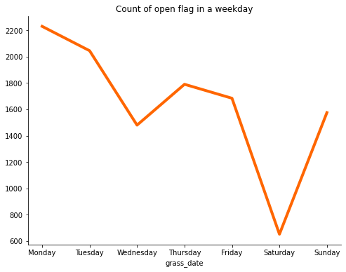

```python
display(HTML('''<p style="font-size:12px;font-style:default;"><b>
Figure 9. Seasonality of users opening their emails on a weekday
</b></p>'''))


df_train['grass_date'] = pd.to_datetime(df_train['grass_date'])

weekday = df_train['grass_date'].apply(lambda x:
                                       calendar.day_name[x.weekday()])

ax = (df_train.groupby(weekday)['open_flag']
      .sum()[[1, -2, -1, -3, 0, 2, 3]]
      .plot(figsize=(8, 6), color='#FF6600', lw=4))

ax.set_title('Count of open flag in a weekday')
ax.spines['top'].set_visible(False)
ax.spines['right'].set_visible(False)
```

Surprisingly, there is a sudden drop in the number of open_flag during Saturdays.

Looking at the users data.

**Figure 10. Correlation of users data to the target variable**

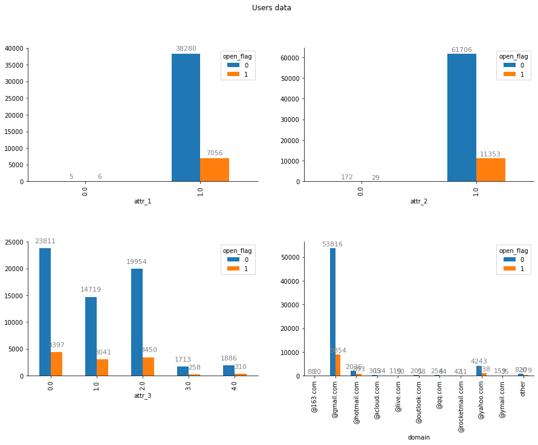

```python
display(HTML('''<p style="font-size:12px;font-style:default;"><b>
Figure 10. Correlation of users data to the target variable
</b></p>'''))

i, j = 0, 0
fig, axes = plt.subplots(2, 2, figsize = (15, 10))
plt.subplots_adjust(hspace = .45)

for attr in ['attr_1', 'attr_2', 'attr_3', 'domain']:
    ct = pd.crosstab(df_train_merge[attr], df_train_merge['open_flag'])
    ct.plot(kind='bar', grid=False, ax=axes[i,j])
    axes[i,j].spines['top'].set_visible(False)
    axes[i,j].spines['right'].set_visible(False)
    bars = axes[i,j].containers

    for nbar in bars:
        for bar in nbar:
            axes[i,j].text(bar.get_x() + bar.get_width()/2,
                           bar.get_height() + 1000,
                           str(int(bar.get_height())),
                 ha='center', color='gray', fontsize=11)


    axes[i, j].spines['top'].set_visible(False)
    axes[i, j].spines['right'].set_visible(False)

    j += 1
    if j == 2:
        i += 1
        j = 0

plt.suptitle('Users data ');
```

**Insights:**

- Surprisingly `attr_1` seems to have a big impact on the open flag. As we can see the number of open flag is larger when attr_1 is 0
- A very high number of gmail users did not open the email, possible that Google mark their email as spam

Does age matter?

**Figure 10. Age Distribution based on target variable**

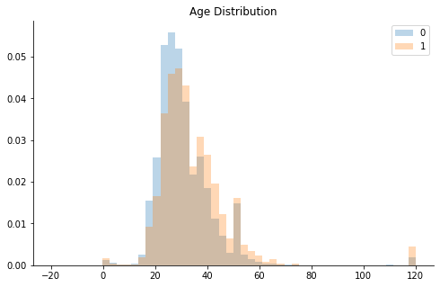

```python
display(HTML('''<p style="font-size:12px;font-style:default;"><b>
Figure 10. Age Distribution based on target variable
</b></p>'''))

fig, ax = plt.subplots(figsize=(8, 5))
for i in range(0,2):
    figsize=(8, 8)
    ax.hist(df_train_merge[(df_train_merge.open_flag == i) ].age,
             bins=50 , label=i, range=[-20,120], density=True, alpha=0.3)

ax.spines['top'].set_visible(False)
ax.spines['right'].set_visible(False)
plt.title('Age Distribution')
plt.legend()
plt.show()
```

**Insights:**

- It seems that older people have more tendency to read emails from Shopee.

Let us try to look at patterns on age difference for each country

**Figure 11. Age difference per country**

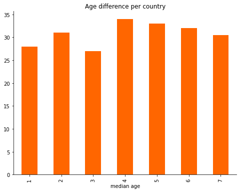

```python
display(HTML('''<p style="font-size:12px;font-style:default;"><b>
Figure 11. Age difference per country
</b></p>'''))

ax = (df_train_merge.groupby('country_code')['age']
      .median().plot.bar(figsize=(8, 6), color='#FF6600'))
ax.spines['top'].set_visible(False)
ax.spines['right'].set_visible(False)

ax.set_xlabel('median age');
ax.set_title('Age difference per country');
```

**Insights:**

- It can be seen that more users from `country_code` = 3, are younger compared to other countries while `country_code` = 4 are older.

## Data Processing (Steps 1-5)

### Step 1: Look at the missing values

On this section, let's try to look at the number of null values in our three datasets

```python
nulls = pd.DataFrame(df_train.isnull().sum())
nulls.columns = ['Number of null values']
display(nulls)
```

|  | Number of null values |
| --- | --- |
| country_code | 0 |
| grass_date | 0 |
| user_id | 0 |
| subject_line_length | 0 |
| last_open_day | 0 |
| last_login_day | 0 |
| last_checkout_day | 0 |
| open_count_last_10_days | 0 |
| open_count_last_30_days | 0 |
| open_count_last_60_days | 0 |
| login_count_last_10_days | 0 |
| login_count_last_30_days | 0 |
| login_count_last_60_days | 0 |
| checkout_count_last_10_days | 0 |
| checkout_count_last_30_days | 0 |
| checkout_count_last_60_days | 0 |
| open_flag | 0 |
| row_id | 0 |

There are no null values in our train data

```python
nulls = pd.DataFrame(df_test.isnull().sum())
nulls.columns = ['Number of null values']
display(nulls)
```

|  | Number of null values |
| --- | --- |
| country_code | 0 |
| grass_date | 0 |
| user_id | 0 |
| subject_line_length | 0 |
| last_open_day | 0 |
| last_login_day | 0 |
| last_checkout_day | 0 |
| open_count_last_10_days | 0 |
| open_count_last_30_days | 0 |
| open_count_last_60_days | 0 |
| login_count_last_10_days | 0 |
| login_count_last_30_days | 0 |
| login_count_last_60_days | 0 |
| checkout_count_last_10_days | 0 |
| checkout_count_last_30_days | 0 |
| checkout_count_last_60_days | 0 |
| row_id | 0 |

There are no null values for our test data

```python
nulls = pd.DataFrame(df_users.isnull().sum())
nulls.columns = ['Number of null values']
display(nulls)
```

|  | Number of null values |
| --- | --- |
| user_id | 0 |
| attr_1 | 48899 |
| attr_2 | 447 |
| attr_3 | 0 |
| age | 48899 |
| domain | 0 |

We have a large number of null values for attr_1, age, and attr_2. It is also noticeable that attr_1 and age have the same number of null values.

```python
((df_users.attr_1.isnull()) | (df_users.age.isnull())).sum()
```

```
48899
```

We can further verify that all null values for age has null attr_1 as well

### Steps 2 and 3. Remove or Impute the missing values

We can use the relation captured earlier on the age difference per country to impute the missing values for the age

```python
for i in range(1,8):
    age = df_train_merge[(df_train_merge.country_code == i)
                         & (~df_train_merge.age.isnull())]['age'].median()
    df_train_merge.loc[(df_train_merge.country_code == i)
                       & (df_train_merge.age.isnull()), 'age'] = age
    df_test_merge.loc[(df_test_merge.country_code == i)
                      & (df_test_merge.age.isnull()), 'age'] = age
```

By using this instead of the mean, I was able to increase my MCC score of up to 1%

for the missing values on attr_1 and attr_2, we wil just use mode to fill the nan values

```python
# Impute attr_1 and attr_2 nan values
df_users['attr_1'].fillna(df_users['attr_1'].mode()[0], inplace=True)
df_users['attr_2'].fillna(df_users['attr_2'].mode()[0], inplace=True)
```

```python
mode = df_train_merge['attr_1'].mode()
df_train_merge.fillna(mode[0], inplace=True)
df_test_merge.fillna(mode[0], inplace=True)
```

```python
nulls = pd.DataFrame(df_train_merge.isnull().sum())
nulls.columns = ['Number of null values']
display(nulls)
```

|  | Number of null values |
| --- | --- |
| country_code | 0 |
| grass_date | 0 |
| subject_line_length | 0 |
| last_open_day | 0 |
| last_login_day | 0 |
| last_checkout_day | 0 |
| open_count_last_10_days | 0 |
| open_count_last_30_days | 0 |
| open_count_last_60_days | 0 |
| login_count_last_10_days | 0 |
| login_count_last_30_days | 0 |
| login_count_last_60_days | 0 |
| checkout_count_last_10_days | 0 |
| checkout_count_last_30_days | 0 |
| checkout_count_last_60_days | 0 |
| open_flag | 0 |
| attr_1 | 0 |
| attr_2 | 0 |
| attr_3 | 0 |
| age | 0 |
| domain | 0 |

```python
nulls = pd.DataFrame(df_test_merge.isnull().sum())
nulls.columns = ['Number of null values']
display(nulls)
```

|  | Number of null values |
| --- | --- |
| country_code | 0 |
| grass_date | 0 |
| subject_line_length | 0 |
| last_open_day | 0 |
| last_login_day | 0 |
| last_checkout_day | 0 |
| open_count_last_10_days | 0 |
| open_count_last_30_days | 0 |
| open_count_last_60_days | 0 |
| login_count_last_10_days | 0 |
| login_count_last_30_days | 0 |
| login_count_last_60_days | 0 |
| checkout_count_last_10_days | 0 |
| checkout_count_last_30_days | 0 |
| checkout_count_last_60_days | 0 |
| attr_1 | 0 |
| attr_2 | 0 |
| attr_3 | 0 |
| age | 0 |
| domain | 0 |

### Step 4. Handle Categorical Data

Create a function that would convert the categorical variables to one hot encode when the model is not catboost

```python
def category_transform(df):
    """
    One hot encode categorical variables if model != catboost
    """
    # Get one hot encoding of categorical columns
    for cat in ['country_code', 'weekday', 'domain']:
        one_hot_encode = pd.get_dummies(df[cat], prefix=cat)
        # Drop column as it is now encoded
        df = df.copy()
        df.drop(cat, axis=1, inplace=True)
        # Join the encoded df
        df = df.join(one_hot_encode)

    return df
```

### Step 5: Feature Transformation

Convert never open/login/checkout to the max value of the feature. Setting it to max value would make it appear to be "never".

```python
for i in ['checkout', 'login', 'open']:
    i = f'last_{i}_day'
    max_count = (df_train_merge[df_train_merge[i].str.isdecimal()]
                    [i].astype('int32').max())
    df_train_merge.loc[~df_train_merge[i].str.isdecimal(),
                       i] = str(max_count)
    df_test_merge.loc[~df_test_merge[i].str
                      .isdecimal(), i] = str(max_count)
    df_train_merge[i] = df_train_merge[i].astype('int32')
    df_test_merge[i] = df_test_merge[i].astype('int32')
```

Convert the grass date to days of week.

```python
def get_date_features(df):
    # Convert date to weekday
    df['grass_date'] = pd.to_datetime(df['grass_date'])
    df['weekday'] = df['grass_date'].apply(lambda x:
                                           x.weekday())
    df = df.drop('grass_date', axis=1)
    return df
```

```python
df_train_merge = get_date_features(df_train_merge)
df_test_merge = get_date_features(df_test_merge)
```

To reduce the correlation between `open_count_last_10_days` and `open_count_last_30_days`, etc. We can convert it to `open_count_10_to_30_days` since `open_count_last_10_days` already represents users on that duration.

```python
def transform_range(df):
    """
    Convert from last 30/60 days to 10/30 to 30/60
    """
    for activity in ['open', 'login', 'checkout']:
        for initdays, findays in zip([10, 30], [30, 60]):
            initcol =  '{}_count_last_{}_days'.format(activity, initdays)
            fincol = '{}_count_last_{}_days'.format(activity, findays)
            newcol = '{}_count_{}_to_{}_days'.format(activity,
                                                     initdays, findays)
            df[newcol] = df[fincol] - df[initcol]
            if initdays == 30:
                df.drop(initcol, axis=1, inplace=True)
                df.drop(fincol, axis=1, inplace=True)
    return df
```

```python
df_train_merge = transform_range(df_train_merge)
df_test_merge = transform_range(df_test_merge)
```

### Step 6: Now let's run an automated Machine Learning to the above processed data

```python
class AutoML(object):
    def __init__(self, model_code):
        self.splits = []
        models = {
            # regressor
            # error based
            'lir': [LinearRegression, 'Linear Regression'],
            'rdg': [Ridge, 'Ridge Regression'],
            'lso': [Lasso, 'Lasso Regression'],
            # information based
            'dtr': [DecisionTreeRegressor, 'Decision Tree'],
            'rfr': [RandomForestRegressor, 'Random Forest'],
            'gbr': [GradientBoostingRegressor, 'GradientBoost'],

            'knr': [KNeighborsRegressor, 'knn Regression'],

            # classifier
            # error based
            'log': [LogisticRegression, 'Logistic Regression'],
            'svl': [LinearSVC, 'Linear SVM'],
            'svm': [SVC, 'SVM'],
            'cbc': [CatBoostClassifier, 'Catboost'],

            # information based
            'dtc': [DecisionTreeClassifier, 'Decision Tree'],
            'rfc': [RandomForestClassifier, 'Random Forest'],
            'gbc': [GradientBoostingClassifier, 'Gradient Boost'],
            # similarity based
            'knc': [KNeighborsClassifier, 'knn Classification'],
        }
        # multiple train
        self.summs = None
        self.test_model = None
        if isinstance(model_code, list):
            if all(map(lambda x: x in models, model_code)):
                self.model_code = model_code
                self.model = [models[i][0] for i in model_code]
                self.model_name = [models[i][1] for i in model_code]
            else:
                raise ValueError('invalid model_code!')
        else:
            if model_code not in models.keys():
                raise ValueError('invalid model_code!')
            self.model_code = model_code
            self.model = models[model_code][0]
            self.model_name = models[model_code][1]
        # used only for appending for model_name
        self.append = True

    def split_data(self, X, y, random_state=1337, shuffle=True,
                   method='train_test', num_trials=1, stratify=False, **kwargs):
        stratify_dict = {}
        if self.splits:
            return self.splits

        if method == 'train_test':
            if stratify:
                stratify_dict['stratify'] = y

            for i in range(num_trials):
                test_size = 0.2 if 'test_size' not in kwargs.keys(
                ) else kwargs['test_size']

                (X_train, X_test,
                 y_train, y_test) = train_test_split(X, y,
                                                     test_size=test_size,
                                                     random_state=i,
                                                     shuffle=shuffle,
                                                     **stratify_dict)

                self.splits.append((X_train, X_test, y_train, y_test))
        elif method == 'kfold':
            n_splits = 8 if 'n_splits' not in kwargs.keys(
            ) else kwargs['n_splits']
            if stratify:
                kf = StratifiedKFold(
                    n_splits=n_splits, shuffle=shuffle,
                    random_state=random_state)
                self.splits = [(X.iloc[i], X.iloc[j], y.iloc[i], y.iloc[j])
                               for (i, j) in kf.split(X, y)]
            else:
                kf = KFold(n_splits=n_splits, shuffle=shuffle,
                           random_state=random_state)
                self.splits = [(X.iloc[i], X.iloc[j], y.iloc[i], y.iloc[j])
                               for (i, j) in kf.split(X)]

        return self.splits

    def generate_summary(self,):
        if self.summs is not None:
            return self.summs
        return [self.model_name, self.test_score, self.matt_score,
                self.best_param,
                self.top_predictor, self.run_time]

    def plot_feature_importance(self, absol=True, sort=True):
        fig, ax = plt.subplots(figsize=(6, 8))
        mean_coefs = self.mean_coefs.copy()
        feature_names = self.feature_names.copy()

        if absol:
            mean_coefs = np.abs(mean_coefs)

        if sort:
            feature_names = feature_names[np.argsort(np.abs(mean_coefs))]
            mean_coefs = sorted(np.abs(mean_coefs))
        ax.set_title(self.model_name)
        ax.barh(np.arange(self.coefs_count), mean_coefs, color='#FF6600')
        ax.set_yticks(np.arange(self.coefs_count))
        ax.set_yticklabels(feature_names)

    def plot_train_val(self, log_scale=False):
        # Initialize figure
        fig, ax = plt.subplots(figsize=(15, 6))
        plt.title(self.model_name, fontsize=16)
        values = [list(param.values())[0] for param in self.param_grid]

        if log_scale:
            plt.xscale('log')

        # Plot the spread of predictions
        ax.fill_between(
            values,
            np.mean(self.score_train, axis=0) +
            np.std(self.score_train, axis=0),
            np.mean(self.score_train, axis=0) -
            np.std(self.score_train, axis=0),
            color='tab:blue', alpha=0.10
        )
        ax.fill_between(
            values,
            np.mean(self.score_test, axis=0) + np.std(self.score_test, axis=0),
            np.mean(self.score_test, axis=0) - np.std(self.score_test, axis=0),
            color='tab:orange', alpha=0.10
        )
        # Plot mean of the predictions
        ax.plot(values, np.mean(self.score_train, axis=0), lw=3,
                label="training accuracy")
        ax.plot(values, np.mean(self.score_test, axis=0), lw=3,
                label="validation accuracy")

        plt.xlabel(list(self.param_grid[0].keys())[0])
        plt.legend()
        plt.ylabel('accuracy')

    def set_model_default_params(self, model):
        default_params = {
            'rfr': {'n_jobs': -1, 'n_estimators': 50},
            'rfc': {'n_jobs': -1, 'n_estimators': 50},
            'gbr': {'n_estimators': 50},
            'gbc': {'n_estimators': 50},
            'cbc': {'loss_function': 'Logloss', 'class_weights': {0: 1, 1: 2},
                    'learning_rate': 0.1, 'logging_level': 'Silent',
                    'task_type': 'CPU'}
        }
```

```python
        if self.model_code in default_params.keys():
            model.set_params(**default_params[self.model_code])

        elif self.model_code == 'log':
            if ('penalty' in self.fixed_params.keys()
                and self.fixed_params['penalty'] == 'l1'):
                default_params = {'solver': 'liblinear'}
            else:
                default_params = {'dual': False}

            model.set_params(**default_params)
            if self.append:
                self.model_name = f'''{self.model_name}
                ({self.fixed_params["penalty"]})'''
                self.append = False

        elif self.model_code == 'svl':
            if ('penalty' in self.fixed_params.keys()
                and self.fixed_params['penalty'] == 'l1'):
                default_params = {'loss': 'squared_hinge', 'dual': False}
                model.set_params(**default_params)
            if self.append:
                self.model_name = f'''{self.model_name}
                ({self.fixed_params["penalty"]})'''
                self.append = False

        return model

    def get_coefs(self, reg):
        if self.model_code in ['dtr', 'dtc',
                               'rfr', 'rfc',
                               'gbr', 'gbc',
                               'cbc']:
            coefs = reg.feature_importances_
        elif self.model_code in ['lir', 'rdg', 'lso', 'log', 'svl']:
            coefs = reg.coef_
        elif self.model_code in ['knr', 'knc']:
            coefs = None

        return coefs

    def train_model(self, X, y,
                    random_state=0, fixed_params={},
                    param_grid={'max_depth': range(2, 11)},
                    normalize=False, plot_train_val=True,
                    plot_feat_imp=True, resample=None):
        if isinstance(self.model_code, list):
            self.train_models_multiple(X, y,
                                       random_state, fixed_params,
                                       param_grid,
                                       normalize, plot_train_val,
                                       plot_feat_imp)
            return

        start_time = time.time()
        score_train = []
        score_test = []
        test_score = []
        training_score = []
        weighted_coefs = []
        param_grid = list(ParameterGrid(param_grid))
        model = self.model
        self.fixed_params = fixed_params
        self.normalize = normalize

        with tqdm(total=len(self.splits), file=sys.stdout,
                  position=0, leave=True) as pbar:
            for split in self.splits:
                pbar.set_description(self.model_name)

                training_accuracy = []
                training_scores = []
                test_accuracy = []
                test_scores = []
                X_train, X_test, y_train, y_test = split

                if normalize:
                    # normalize the features
                    Scaler = normalize().fit(X_train)
                    X_train = Scaler.transform(X_train)
                    X_test = Scaler.transform(X_test)

                if resample:
                    X_train, y_train = resample.fit_resample(X_train, y_train)

                if self.model_code in ['lir']:
                    mdl = model()
                    mdl.fit(X_train, y_train)
                    training_accuracy.append(mdl.score(X_train, y_train))
                    test_accuracy.append(mdl.score(X_test, y_test))
                    coefs = self.get_coefs(mdl)
                    weighted_coefs.append(coefs)
                else:
                    for param in param_grid:
                        try:
                            mdl = model(random_state=random_state,
                                        **param)
                        except TypeError:
                            mdl = model(**param)

                        mdl = self.set_model_default_params(mdl)
                        try:
                            mdl.set_params(**fixed_params)
                        except KeyError:
                            pass

                        mdl.fit(X_train, y_train)

                        training_accuracy.append(mdl.score(X_train, y_train))
                        y_hat = mdl.predict(X_train)
                        training_scores.append(
                            matthews_corrcoef(y_train, y_hat))
                        test_accuracy.append(mdl.score(X_test, y_test))
                        y_hat = mdl.predict(X_test)
                        test_scores.append(matthews_corrcoef(y_test, y_hat))

                        coefs = self.get_coefs(mdl)
                        weighted_coefs.append(coefs)
                pbar.update(1)

                score_train.append(training_accuracy)
                training_score.append(training_scores)
                score_test.append(test_accuracy)
                test_score.append(test_scores)

        # get the mean of the weighted coefficients over all the trials
        mean_coefs = None if self.model_code in [
            'knr', 'knc'] else np.mean(weighted_coefs, axis=0)
        mean_coefs = (None if self.model_code in ['knr', 'knc']
                      else (mean_coefs if mean_coefs.ndim == 1
                            else mean_coefs.mean(axis=0)))
        score = np.mean(test_score, axis=0)
        top_predictor = 'NA' if self.model_code in [
            'knr', 'knc'] else X.columns[np.argmax(np.abs(mean_coefs))]

        # for plotting train and test accuracy
        self.score_train = score_train
        self.score_test = score_test
        self.param_grid = param_grid

        # for plotting feature importance
        self.mean_coefs = None if self.model_code in [
            'knr', 'knc'] else mean_coefs
        self.coefs_count = None if self.model_code in [
            'knr', 'knc'] else len(self.mean_coefs)
        self.feature_names = X.columns

        # for summary
        self.matt_score = np.amax(score)
        self.test_score = np.mean(score_test, axis=0)[np.argmax(score)]
        best_param = [f'{key} =  {value}'
                      for key, value in param_grid[np.argmax(score)].items()]
        self.best_param = ';'.join(
            best_param) if self.model_code != 'lir' else 'NA'
        self.top_predictor = top_predictor
        self.run_time = (time.time() - start_time)
```

```python
        # for score
        self.test_param = param_grid[np.argmax(score)]

        if plot_train_val:
            if self.model_code == 'lir':
                pass
            elif self.model_code not in ['log', 'svl']:
                self.plot_train_val()
            else:
                self.plot_train_val(log_scale=True)

        if plot_feat_imp:
            if self.model_code not in ['knr', 'knc']:
                self.plot_feature_importance()

    def train_models_multiple(self, X, y,
                              random_state=0, fixed_params={},
                              param_grid={'max_depth': range(2, 11)},
                              normalize=False, plot_train_val=True,
                              plot_feat_imp=True):
        """should have the same params"""
        model_codes = self.model_code
        models = self.model
        model_names = self.model_name
        summs = []
        for model_code, model, model_name in zip(model_codes, models, model_names):
            self.append = True
            self.model_code = model_code
            self.model = model
            self.model_name = model_name
            self.train_model(X, y, random_state, fixed_params,
                             param_grid,
                             normalize, plot_train_val,
                             plot_feat_imp)
            summs.append(self.generate_summary())

        summs = pd.DataFrame(summs)
        summs.columns = ['Machine Learning Method', 'Test Accuracy', 'MCC',
                         'Best Parameter', 'Top Predictor Variable', 'Run Time']

        self.summs = summs

    def score(self, X, y):
        """ Works for single model only"""
        if self.test_model is None:
            X_train, X_test, y_train, y_test = self.splits[0]

            if self.normalize:
                # normalize the features
                Scaler = self.normalize().fit(X_train)
                X_train = Scaler.transform(X_train)
                X_test = Scaler.transform(X_test)
                self.test_scaler = Scaler

            test_model = self.model()
            test_model = self.set_model_default_params(test_model)
            try:
                test_model.set_params(**self.fixed_params)
            except KeyError:
                pass

            test_model.set_params(**self.test_param)
            test_model.fit(X_train, y_train)
            self.test_model = test_model

        if self.normalize:
            X = self.test_scaler.transform(X)

        return self.test_model.score(X, y)
```

## E. Results and Discussions

### i. Matthews Correlation Coefficient

Matthews Correlation Coefficient (MCC) is used when it is important to have a good accuracy at the four quadrants of the confusion matrix. As we can see in the formula:

**Figure 12. MCC formula**

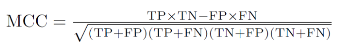

Matthews Correlation Coefficient solves the problem of being asymmetric of f1 score and the problem of being sensitive to class imbalance for accuracy$^3$. It ranges from -1 to 1 with 1 being perfectly prediction.

### ii. Model Summary

|  | Machine Learning Method | Test Accuracy | MCC | Best Parameter | Top Predictor Variable | Run Time |
| --- | --- | --- | --- | --- | --- | --- |
| 0 | Catboost | 0.880718 | 0.538533 | max_depth = 5 | open_count_last_10_days | 385.282972 |

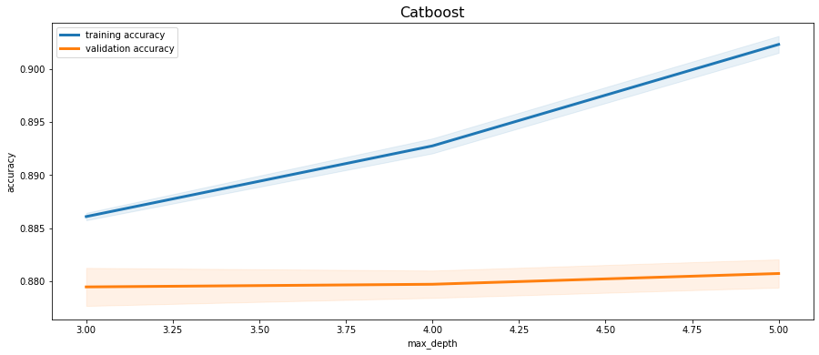

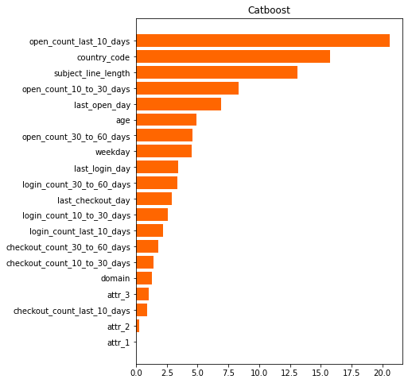

```python
X = df_train_merge.drop(['open_flag'], axis=1)
y = df_train_merge['open_flag']

max_depth = list(range(3, 6))

automl_cat = AutoML(['cbc'])
splits = automl_cat.split_data(X, y, shuffle=True, num_trials=5,
                                test_size=0.25, stratify=True)
automl_tree.train_model(X, y, param_grid={'max_depth':max_depth})
cat_summary = automl_cat.generate_summary()
cat_summary
```

```python
X = category_transform(df_train_merge).drop('open_flag', axis=1)
y = category_transform(df_train_merge)['open_flag']

C = [1e-3, .01, 0.1, 10, 100]
n_neighbors = list(range(1, 10))
max_depth = list(range(1, 10))
hidden_layer_sizes = [tuple([100])]

automl_tree = AutoML(['dtc', 'rfc', 'gbc'])
splits = automl_tree.split_data(X, y, shuffle=True, num_trials=5,
                                test_size=0.25, stratify=True)
automl_tree.train_model(X, y, param_grid={'max_depth':max_depth})
tree_summary = automl_tree.generate_summary()

automl_linear_l1 = AutoML(['log', 'svl'])
splits = automl_linear_l1.split_data(X, y, shuffle=True, num_trials=5,
                                     test_size=0.25, stratify=True)
automl_linear_l1.train_model(X, y, param_grid= {'C' : C},
                        fixed_params={'penalty' : 'l1'},
                             normalize=MinMaxScaler)
linearl1_summary = automl_linear_l1.generate_summary()

automl_linear_l2 = AutoML(['log', 'svl'])
splits = automl_linear_l2.split_data(X, y, shuffle=True,
                                     num_trials=5, test_size=0.25,
                                     stratify=True)
automl_linear_l2.train_model(X, y, param_grid= {'C' : C},
                        fixed_params={'penalty' : 'l2'},
                             normalize=MinMaxScaler)
linearl2_summary = automl_linear_l2.generate_summary()

automl_nn = AutoML(['mlp'])
splits = automl_nn.split_data(X, y, shuffle=True, num_trials=1,
                                     test_size=0.25, stratify=True)
automl_nn.train_model(X, y, param_grid= {'hidden_layer_sizes' : hidden_layer_sizes},
                             normalize=MinMaxScaler)
nn_summary = automl_nn.generate_summary()


df = pd.concat([tree_summary,
                linearl1_summary,
                linearl2_summary,
                nn_summary,
                cat_summary]).reset_index(drop=True)

# save to csv file
df.to_csv('MLsummary.csv', index=False)
```

**Table 8. Summary of Results.**

| Machine Learning Method | MCC | Best Parameter | Top Predictor Variable | Run Time |
| --- | --- | --- | --- | --- |
| Decision Tree | 0.496266 | max_depth = 7 | open_count_last_10_days | 12.923535 |
| Random Forest | 0.485531 | max_depth = 9 | open_count_last_10_days | 77.147337 |
| Gradient Boost | 0.524928 | max_depth = 7 | open_count_last_10_days | 533.795736 |
| Logistic Regression (l1) | 0.499538 | C = 100 | open_count_last_10_days | 156.180306 |
| Linear SVM (l1) | 0.485496 | C = 10 | open_count_last_10_days | 112.788091 |
| Logistic Regression (l2) | 0.498932 | C = 100 | open_count_last_10_days | 204.796414 |
| Linear SVM (l2) | 0.485513 | C = 10 | open_count_last_10_days | 165.198988 |
| Catboost | 0.538533 | max_depth = 5 | open_count_last_10_days | 385.282972 |
| MLP classifier | 0.509266 | hidden_layer_sizes = (100,) | NA | 1808.343314 |
| Naïve Bayes | 0.445972 | alpha = 1 | NA | 0.863 |

### iii. Resampling Method

- SMOTE
- ADASYN
- SMOTE-NC

SMOTE-NC (or Synthetic Minority Over-sampling Technique-Nominal Continuous) is a variation of SMOTE that handles both numerical and categorical features. Compared to SMOTE, the difference of categorical features is now considered when computing for the median and k-nearest neighbors. The values for said features are then determined based on the values appearing for most of the k-nearest neighbors. To determine the categorical features, the implementation of this resampling technique in ‘imblearn’ requires a list of indices that represent these features.

```python
X = category_transform(df_train_merge).drop('open_flag', axis=1)
y = category_transform(df_train_merge)['open_flag']
cats = X.columns[7:9].to_list() + X.columns[17:].to_list()
res_methods = [SMOTE(sampling_strategy=0.6, n_jobs=-1, random_state=143),
               ADASYN(sampling_strategy=0.6, n_jobs=-1, random_state=143),
               SMOTENC(sampling_strategy=0.6, n_jobs=-1, random_state=143,
                       categorical_features=cats)
            ]
summary_dict = {}
for k in range(3, 7):
    for resample, names in zip(res_methods, ['SMOTE', 'ADASYN', 'SMOTENC']):
        automl_tree = AutoML(['cbc'])
        try:
            resample.set_params(k_neighbors=k)
        except Exception as e:
            resample.set_params(n_neighbors=k)


        splits = automl_tree.split_data(X, y, shuffle=True, num_trials=1,
                                        test_size=0.25, stratify=True)
        automl_tree.train_model(X, y, param_grid={'max_depth':max_depth},
                                resample=resample)
        summary_dict[(names, k)] = automl_tree.generate_summary()
```

```python
res_dict = {key: value.to_dict() for key, value, in summary_dict.items()}
res_dict = pd.DataFrame(res_dict).T
display(res_dict)
```

|  |  | Machine Learning Method | Test Accuracy | MCC | Best Parameter | Top Predictor Variable | Run Time |
| --- | --- | --- | --- | --- | --- | --- | --- |
| SMOTE | 3 | {0: 'Catboost'} | {0: 0.88245852597226} | {0: 0.5448299123673186} | {0: 'max_depth = 5'} | {0: 'open_count_last_10_days'} | {0: 30.215125799179077} |
| ADASYN | 3 | {0: 'Catboost'} | {0: 0.8809899374490073} | {0: 0.5423948812147934} | {0: 'max_depth = 3'} | {0: 'open_count_last_10_days'} | {0: 27.82874870300293} |
| SMOTENC | 3 | {0: 'Catboost'} | {0: 0.8830024476475388} | {0: 0.5464378747807244} | {0: 'max_depth = 5'} | {0: 'open_count_last_10_days'} | {0: 29.124675750732422} |
| SMOTE | 4 | {0: 'Catboost'} | {0: 0.8830024476475388} | {0: 0.5464378747807244} | {0: 'max_depth = 5'} | {0: 'open_count_last_10_days'} | {0: 29.402430772781372} |
| ADASYN | 4 | {0: 'Catboost'} | {0: 0.8808267609464238} | {0: 0.543371170893529} | {0: 'max_depth = 3'} | {0: 'open_count_last_10_days'} | {0: 28.337640047073364} |
| SMOTENC | 4 | {0: 'Catboost'} | {0: 0.8813162904541746} | {0: 0.5426298395114778} | {0: 'max_depth = 4'} | {0: 'open_count_last_10_days'} | {0: 29.131855010986328} |
| SMOTE | 5 | {0: 'Catboost'} | {0: 0.8818602121294533} | {0: 0.5443465083980493} | {0: 'max_depth = 4'} | {0: 'open_count_last_10_days'} | {0: 27.786059141159058} |
| ADASYN | 5 | {0: 'Catboost'} | {0: 0.8814794669567583} | {0: 0.5440866117291189} | {0: 'max_depth = 3'} | {0: 'open_count_last_10_days'} | {0: 28.551926136016846} |
| SMOTENC | 5 | {0: 'Catboost'} | {0: 0.881153113951591} | {0: 0.542830812918497} | {0: 'max_depth = 3'} | {0: 'open_count_last_10_days'} | {0: 28.84685492515564} |
| SMOTE | 6 | {0: 'Catboost'} | {0: 0.8817514277943976} | {0: 0.5421527096197691} | {0: 'max_depth = 5'} | {0: 'open_count_last_10_days'} | {0: 28.374662399291992} |
| ADASYN | 6 | {0: 'Catboost'} | {0: 0.8817514277943976} | {0: 0.5421527096197691} | {0: 'max_depth = 5'} | {0: 'open_count_last_10_days'} | {0: 28.669580459594727} |
| SMOTENC | 6 | {0: 'Catboost'} | {0: 0.8830024476475388} | {0: 0.5464378747807244} | {0: 'max_depth = 5'} | {0: 'open_count_last_10_days'} | {0: 28.153640747070312} |

### iv. Is our model good enough?

**Figure 14. Snippet of leadeboard in kaggle**

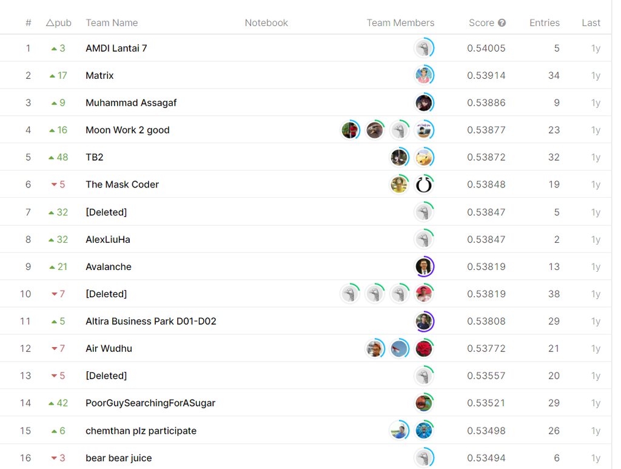

## F. Model Interpretability

### i. SHAP

The first thing that we want to see is the feature importance and how it affects the model. We can see that by using Shapley values and more specifically Summary plot. The summary plot combines feature importance with feature effects. Each point on the summary plot is a Shapley value for a feature and an instance. It is arrange from top to bottom on how important the feature is.

```
100%|===================| 18367/18385 [05:55<00:00]
```

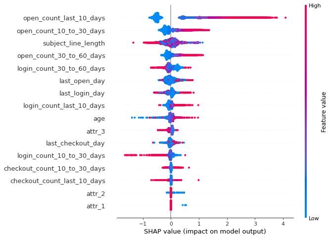

```python
# get x and y
X = category_transform(df_train_merge).drop('open_flag', axis=1)
y = category_transform(df_train_merge)['open_flag']
X_train, X_test, y_train, y_test = train_test_split(X, y,
                                                    test_size=0.25,
                                                    random_state=143,
                                                    shuffle=True,
                                                    stratify=y)
# resample using SMOTE
resample = SMOTE(sampling_strategy=0.6,
                 n_jobs=-1,
                 random_state=143,
                 k_neighbors=3)
X_train, y_train = resample.fit_resample(X_train, y_train)

# train model
params = {'loss_function' : 'Logloss', 'class_weights': {0:1, 1:2},
          'learning_rate' : 0.1,'logging_level':'Silent',
          'max_depth' :4 }
model = CatBoostClassifier(**params)
model.fit(X_train, y_train)

# Compute for shap values and plot
explainer = shap.TreeExplainer(model, X_test)

shap_values = explainer.shap_values(X_test)

shap.summary_plot(shap_values=shap_values[:, :16],
                  features=X_test.iloc[:, :16],
                  feature_names=X_test.columns[:16])
```

The results of summary plot shows that the history of the open count of a user highly determines its tendency to open an email again. Interstingly we can also see that the subject line length shows that the shorter the subject is then it is more likely to be opened by the user. In addition, age seems to correlate with the tendency of a user to open. We can see that the older the user is then it has more tendency to open an email again.

### ii. Accumulated Local Effects (ALE) Plot

Using ALE Plot which is similar to PDP but uses a small window of feature instead of all data instances. With this, it solve the problem of PDP plots that it treats all of the features independent to each other and hence create instances that are impossible to happen in real life scenario.

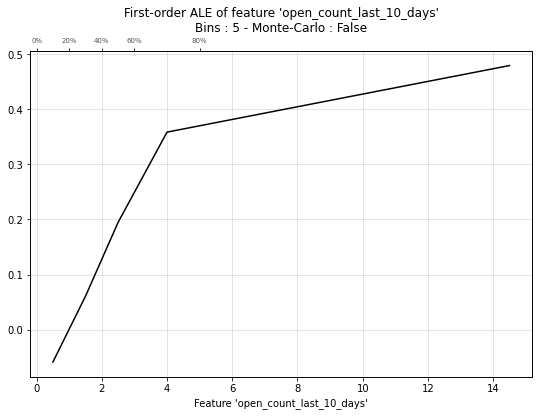

```python
# ale plot of open count last 10 days
cm.rc("figure", figsize=(9, 6))
ale_plot(
    model,
    X_test,
    'open_count_last_10_days',
    bins=20,
)
```

We can see for the open count last 10 days that there is a rapid increase on the first four counts then slowly grow as the count increases

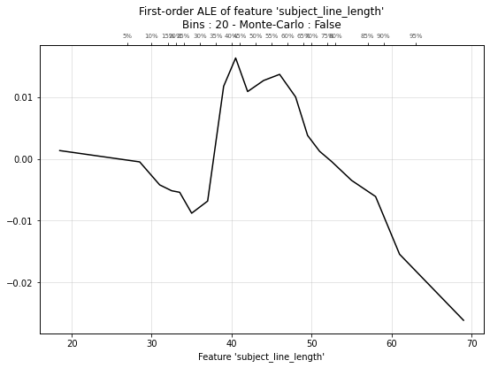

```python
# ale plot of subject line length
cm.rc("figure", figsize=(9, 6))
ale_plot(
    model,
    X_test,
    'subject_line_length',
    bins=20,
)
```

For the subject line length, there is a sweet spot in 40 to 50 characters.

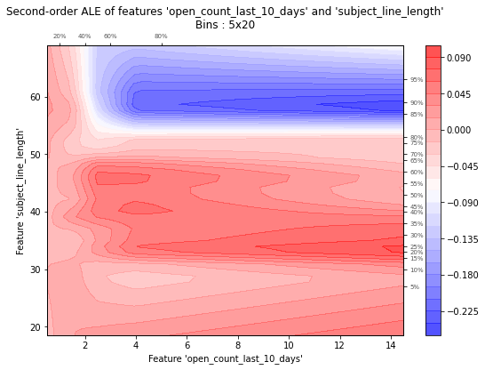

```python
# plot second order ALE plot
cm.rc("figure", figsize=(9, 6))
ale_plot(
    model,
    X_test,
    ['open_count_last_10_days', 'subject_line_length'],
    bins=20,
)
```

### iii. RuleFit

The RuleFit algorithm learns sparse linear models that include automatically detected interaction effects in the form of decision rules. It uses a tree based model then evaluate it on lasso regression to reduce the number of rules. It has 5 major components: Rule, Type, Coef, Support, Feature Importance.

```python
# Create and Train RuleFit Model
rulefit = RuleFit(tree_generator=RandomForestRegressor(n_estimators = 100))
rulefit.fit(X.values, y, feature_names=X.columns)

# calculate rmse
rulefit_preds = rulefit.predict(X.values)
rulefit_rmse = np.sqrt(((rulefit_preds - y) ** 2).mean())
print(rulefit_rmse)
# get rules
rules = rulefit.get_rules()
rules = rules.sort_values('support', ascending=False)
rules
```

|  | rule | type | coef | support | importance |
| --- | --- | --- | --- | --- | --- |
| 0 | subject_line_length | linear | -0.000090 | 1.000000 | 0.000985 |
| 33 | domain_@hotmail.com | linear | -0.009156 | 1.000000 | 0.001791 |
| 24 | weekday_0 | linear | 0.017964 | 1.000000 | 0.007147 |
| 26 | weekday_2 | linear | -0.007361 | 1.000000 | 0.002336 |
| 27 | weekday_3 | linear | -0.006519 | 1.000000 | 0.002354 |
| ... | ... | ... | ... | ... | ... |
| 47 | country_code_4 <= 0.5 & open_count_last_10_day... | rule | 0.121113 | 0.004943 | 0.008494 |
| 85 | country_code_4 <= 0.5 & open_count_last_10_day... | rule | 0.096076 | 0.004491 | 0.006424 |
| 61 | open_count_last_10_days <= 2.5 & country_code_... | rule | 0.045225 | 0.004491 | 0.003024 |
| 108 | country_code_4 <= 0.5 & open_count_last_10_day... | rule | 0.161985 | 0.003406 | 0.009438 |
| 79 | country_code_4 <= 0.5 & open_count_30_to_60_da... | rule | 0.096938 | 0.002649 | 0.004983 |

160 rows × 5 columns

```python
# Get the rules
rules = rulefit.get_rules()
# Eliminate the existing explanatory variables
rules = rules[rules['type']!='linear']
# eliminate the insignificant rules
rules = rules[rules['coef'] != 0]
# Sort the rules based on "support" value
rules = rules.sort_values('support', ascending=False)

# get rules without duplicate features
rule_split = rules.rule.str.split(' <= | >= | > | < | & ')
rules[rule_split.apply(lambda x:[i for i in x if len(i) > 3])
      .apply(lambda x : len(set(x)) == len(x))]
```

|  | rule | type | coef | support | importance |
| --- | --- | --- | --- | --- | --- |
| 57 | open_count_last_10_days <= 2.5 | rule | -0.07 | 0.88 | 0.02 |
| 59 | open_count_last_10_days > 1.5 | rule | 0.07 | 0.20 | 0.03 |
| 72 | open_count_last_10_days > 1.5 & open_count_10_to_30_days > 5.5 | rule | 0.03 | 0.09 | 0.01 |
| 69 | open_count_10_to_30_days > 6.5 & open_count_last_10_days > 1.5 | rule | 0.01 | 0.07 | 0.00 |
| 107 | country_code_4 > 0.5 & open_count_last_10_days <= 1.5 | rule | -0.03 | 0.06 | 0.01 |
| 85 | country_code_4 <= 0.5 & open_count_last_10_days > 2.5 & country_code_5 > 0.5 & open_count_10_to_30_days <= 5.5 | rule | 0.10 | 0.00 | 0.01 |

## G. Conclusion

Shopee is the leading e-commerce in southeast Asia and continuously growing amidst the pandemic$^1$. They started their operation in Singapore in 2015. They could expand to 10 more countries in just six years, namely the Philippines, Malaysia, Thailand, Taiwan, Indonesia, Vietnam, Brazil, Mexico, Chile, and Colombia. One of the secrets to its success is its sophisticated business model that uses Artificial Intelligence to gather insights from the users.$^2$.

In this study, I explored one of the applications of AI in marketing: Predicting when a user would open an email sent by Shopee. I started by performing exploratory data analysis on the distribution, correlation, and correction of our data and finding useful patterns that can be used for our analysis. I saw that most of the users do not open/login/checkout within two months, but those who open an email recently are most likely to open it again. I then see that age slightly plays a factor in the opening of emails by Shopee. As it turns out, older people tend to read an email compared to the younger generation. On a side note, by performing exploratory data analysis, I also saw that our dataset is not that clean where I got an age that is negative and too high of a number that is older than that of the oldest person in the world. It seems that at the time they created the dataset, there was a problem in the app of Shoppee, where a user can enter any birthdate.

I then used model interpretability and saw how the features affect the target variable in the summary plot. I noticed that a high open count of users tends to open an email again. I also noticed that subject line length and age play an important role in the model's decision. I then inspected features using the Accumulated Local Effects (ALE) Plot that I think are relevant to the study and further verified the results. I then used the RuleFit model to create rule-based decisions and saw that some countries do not prefer email as a platform.

Some of my recommendation to Shopee drawn from the models is that they can: Understand existing users who recently opened their email because they are likely to open it again, There is an optimal subject line length of 40 to 50 characters, and Consider targeting older people as they are more likely to read mails, and be aware on the country of the user because some countries may not prefer email as a medium at all.

## H. References

[1] Michael O'Neill (2020) "How 5-year-old startup Shopee is leading e-commerce growth in Southeast Asia" https://www.businessinsider.com/shopees-digital-inclusion-strategy-e-commerce-growth-in-southeast-asia-2020-11

[2] Samantha Cheh (2019) "Here’s how Shopee is developing the next generation of data science and AI talent" https://www.techinasia.com/heres-shopee-developing-generation-data-science-ai-talent

[3] Shmueli Boaz (2019) "Matthews Correlation Coefficient is The Best Classification Metric You’ve Never Heard Of" https://towardsdatascience.com/the-best-classification-metric-youve-never-heard-of-the-matthews-correlation-coefficient-3bf50a2f3e9a